# MiCM: 05 - motif and enrichment

Ariel Madrigal Aguirre

2023-10-25

[figure not shown]

This workshop will guide you through the basics of ChIP-seq analysis with hands-on exercises. You will learn how to process ChIP-seq data: perform read alignment, peak calling, quality control, visualization through the genome browser, motif finding and gene set enrichment analysis.

In this tutorial, we are going to perform motif finding and gene set enrichment analysis. For both tasks, we are going to use a bed file from the data folder, which has the peak calls for HIF1a across the whole genome.

**Note**: The first section (Motif finding) will use the terminal. The second section will use R.

Let’s move to the scripts directory (or stay here if already there):

```bash
cd chip_seq/scripts
```

Let’s take a look at our bed file:

```bash
head ../data/complete/RCC4_Normoxia_HIF1a_PM14_Rep1.bed
```

```
chr1    827430  827761  test_peak_1 144 .
chr1    1019597 1019967 test_peak_2 324 .
chr1    1079402 1080118 test_peak_3 116 .
chr1    1505040 1505335 test_peak_4 121 .
chr1    1614069 1614459 test_peak_5 174 .
chr1    2208006 2208234 test_peak_6 35  .
chr1    2314901 2315258 test_peak_7 96  .
chr1    6701533 6701823 test_peak_8 64  .
chr1    6784797 6785021 test_peak_9 28  .
chr1    8202139 8202582 test_peak_10    508 .
```

Count the number of peaks:

```bash
wc -l ../data/complete/RCC4_Normoxia_HIF1a_PM14_Rep1.bed
```

```
2927 ../data/complete/RCC4_Normoxia_HIF1a_PM14_Rep1.bed
```

# 01 - Motif finding

For motif finding, we are going to use [MEME](https://meme-suite.org/meme/tools/meme-chip). For this tutorial, we are going to use the online interactive suite, but you can download/install meme locally by following the instructions in [here](https://meme-suite.org/meme/doc/download.html). There is also a R package that connects the installation to R, you can check it [here](https://bioconductor.org/packages/release/bioc/html/memes.html).

If the online job takes too long, you can also explore the results in here:

```bash
ls ../answers/meme/HIF1a
```

```
background
centrimo_msgs.txt
centrimo_out
combined.meme
fimo_out_1
fimo_out_2
fimo_out_3
fimo_out_4
fimo_out_5
meme-chip.html
meme_out
meme_tomtom_out
messages.txt
motif_alignment.txt
progress_log.txt
RCC4_Normoxia_HIF1a_PM14_Rep1.bed
seqs-centered
spamo1_msgs.txt
spamo2_msgs.txt
spamo3_msgs.txt
spamo4_msgs.txt
spamo5_msgs.txt
spamo_out_1
spamo_out_2
spamo_out_3
spamo_out_4
spamo_out_5
streme_out
streme_tomtom_out
summary.tsv
```

Open the meme chip results.

# 02 - Gene set enrichment analysis

**Note**: The next chunks show R code.

For gene set enrichment analysis, we are going to use [GREAT](http://great.stanford.edu/public/html/index.php). For this tutorial, we are going to use the R package that allows you to use GREAT, you can check it [here](https://bioconductor.org/packages/release/bioc/html/rGREAT.html).

Loading library

```r
library(rGREAT)
```

```r
inp_bed<- read.table("../data/complete/RCC4_Normoxia_HIF1a_PM14_Rep1.bed")
colnames(inp_bed)<- c("chr", "start", "end", "name", "score", "strand")
head(inp_bed)
```

|  | chr | start | end | name | score | strand |
| --- | --- | --- | --- | --- | --- | --- |
| 1 | chr1 | 827430 | 827761 | test_peak_1 | 144 | . |
| 2 | chr1 | 1019597 | 1019967 | test_peak_2 | 324 | . |
| 3 | chr1 | 1079402 | 1080118 | test_peak_3 | 116 | . |
| 4 | chr1 | 1505040 | 1505335 | test_peak_4 | 121 | . |
| 5 | chr1 | 1614069 | 1614459 | test_peak_5 | 174 | . |
| 6 | chr1 | 2208006 | 2208234 | test_peak_6 | 35 | . |

```r
gr<- makeGRangesFromDataFrame(inp_bed)
job = submitGreatJob(gr, species="hg38")
job
```

```
Submit time: 2023-10-22 21:56:36
  Note the results may only be avaiable on GREAT server for 24 hours.
Version: 4.0.4
Species: hg38
Inputs: 2927 regions
Mode: Basal plus extension
  Proximal: 5 kb upstream, 1 kb downstream,
  plus Distal: up to 1000 kb
Include curated regulatory domains

Enrichment tables for following ontologies have been downloaded:
  None
```

## Get enrichment tables

```r
tbl = getEnrichmentTables(job)
```

[output not shown]

```r
names(tbl)
```

```
[1] "GO Molecular Function" "GO Biological Process" "GO Cellular Component"
```

[output not shown]

```r
head(tbl[["GO Biological Process"]])
```

|  | ID | name | Binom_Genome_Fraction | Binom_Expected | Binom_Observed_Region_Hits | Binom_Fold_Enrichment | Binom_Region_Set_Coverage | Binom_Raw_PValue | Binom_Adjp_BH | Hyper_Total_Genes | Hyper_Expected | Hyper_Observed_Gene_Hits | Hyper_Fold_Enrichment | Hyper_Gene_Set_Coverage | Hyper_Term_Gene_Coverage | Hyper_Raw_PValue | Hyper_Adjp_BH |
| --- | --- | --- | --- | --- | --- | --- | --- | --- | --- | --- | --- | --- | --- | --- | --- | --- | --- |
| 1 | GO:0044237 | cellular metabolic process | 0.61230620 | 1792.22000 | 2055 | 1.146623 | 0.70208400 | 2.134635e-24 | 2.808966e-20 | 8847 | 1666.96900 | 1919 | 1.151191 | 0.54239680 | 0.2169097 | 2.804700e-21 | 3.690705e-17 |
| 2 | GO:0001666 | response to hypoxia | 0.03085340 | 90.30789 | 199 | 2.203573 | 0.06798770 | 5.230312e-24 | 3.441284e-20 | 335 | 63.12137 | 114 | 1.806044 | 0.03222159 | 0.3402985 | 2.161941e-11 | 3.556123e-09 |
| 3 | GO:0036293 | response to decreased oxygen levels | 0.03142986 | 91.99521 | 200 | 2.174026 | 0.06832935 | 1.836844e-23 | 8.057010e-20 | 343 | 64.62875 | 115 | 1.779394 | 0.03250424 | 0.3352770 | 5.101017e-11 | 8.185888e-09 |
| 4 | GO:0070482 | response to oxygen levels | 0.03299069 | 96.56376 | 204 | 2.112594 | 0.06969593 | 1.666392e-22 | 5.109545e-19 | 367 | 69.15088 | 119 | 1.720875 | 0.03363482 | 0.3242507 | 2.557509e-10 | 3.781378e-08 |
| 5 | GO:0044238 | primary metabolic process | 0.61210810 | 1791.64000 | 2043 | 1.140296 | 0.69798430 | 1.941464e-22 | 5.109545e-19 | 8934 | 1683.36200 | 1920 | 1.140575 | 0.54267950 | 0.2149093 | 5.716244e-19 | 7.522005e-16 |
| 6 | GO:0071704 | organic substance metabolic process | 0.63727810 | 1865.31300 | 2112 | 1.132250 | 0.72155790 | 2.357522e-22 | 5.170439e-19 | 9327 | 1757.41200 | 2001 | 1.138606 | 0.56557380 | 0.2145384 | 5.293404e-20 | 1.674800e-16 |

```r
head(tbl[["GO Molecular Function"]])
```

|  | ID | name | Binom_Genome_Fraction | Binom_Expected | Binom_Observed_Region_Hits | Binom_Fold_Enrichment | Binom_Region_Set_Coverage | Binom_Raw_PValue | Binom_Adjp_BH | Hyper_Total_Genes | Hyper_Expected | Hyper_Observed_Gene_Hits | Hyper_Fold_Enrichment | Hyper_Gene_Set_Coverage | Hyper_Term_Gene_Coverage | Hyper_Raw_PValue | Hyper_Adjp_BH |
| --- | --- | --- | --- | --- | --- | --- | --- | --- | --- | --- | --- | --- | --- | --- | --- | --- | --- |
| 1 | GO:0005488 | binding | 0.8504330000 | 2489.2170000 | 2663 | 1.069814 | 0.909805300 | 5.107829e-22 | 2.156525e-18 | 14398 | 2712.900000 | 2907 | 1.071547 | 0.8216507000 | 0.2019030 | 1.100124e-18 | 2.322362e-15 |
| 2 | GO:0005515 | protein binding | 0.7330151000 | 2145.5350000 | 2333 | 1.087374 | 0.797061800 | 4.636027e-16 | 9.786653e-13 | 11170 | 2104.674000 | 2348 | 1.115612 | 0.6636518000 | 0.2102059 | 6.470190e-21 | 2.731714e-17 |
| 3 | GO:0043183 | vascular endothelial growth factor receptor 1 binding | 0.0001485297 | 0.4347463 | 13 | 29.902490 | 0.004441408 | 2.074077e-15 | 2.391930e-12 | 2 | 0.376844 | 2 | 5.307236 | 0.0005652911 | 1.0000000 | 3.549471e-02 | 5.719796e-01 |
| 4 | GO:0003723 | RNA binding | 0.1168352000 | 341.9765000 | 486 | 1.421150 | 0.166040300 | 2.266158e-15 | 2.391930e-12 | 1638 | 308.635200 | 396 | 1.283068 | 0.1119276000 | 0.2417582 | 1.168412e-08 | 2.144798e-06 |
| 5 | GO:0019899 | enzyme binding | 0.1676840000 | 490.8110000 | 620 | 1.263215 | 0.211821000 | 3.340186e-10 | 2.820453e-07 | 1895 | 357.059700 | 484 | 1.355516 | 0.1368005000 | 0.2554090 | 1.886640e-14 | 1.991349e-11 |
| 6 | GO:0019200 | carbohydrate kinase activity | 0.0017247250 | 5.0482690 | 24 | 4.754104 | 0.008199522 | 9.152638e-10 | 6.440406e-07 | 21 | 3.956862 | 10 | 2.527255 | 0.0028264560 | 0.4761905 | 2.558014e-03 | 1.349992e-01 |

```r
head(tbl[["GO Cellular Component"]])
```

|  | ID | name | Binom_Genome_Fraction | Binom_Expected | Binom_Observed_Region_Hits | Binom_Fold_Enrichment | Binom_Region_Set_Coverage | Binom_Raw_PValue | Binom_Adjp_BH | Hyper_Total_Genes | Hyper_Expected | Hyper_Observed_Gene_Hits | Hyper_Fold_Enrichment | Hyper_Gene_Set_Coverage | Hyper_Term_Gene_Coverage | Hyper_Raw_PValue | Hyper_Adjp_BH |
| --- | --- | --- | --- | --- | --- | --- | --- | --- | --- | --- | --- | --- | --- | --- | --- | --- | --- |
| 1 | GO:0005622 | intracellular | 0.8286551 | 2425.473 | 2726 | 1.123904 | 0.9313290 | 1.526922e-60 | 2.638521e-57 | 14472 | 2726.843 | 2990 | 1.096506 | 0.8451102 | 0.2066059 | 7.445893e-34 | 6.433252e-31 |
| 2 | GO:0044424 | intracellular part | 0.8161994 | 2389.016 | 2698 | 1.129335 | 0.9217629 | 1.176871e-59 | 1.016817e-56 | 14132 | 2662.780 | 2940 | 1.104109 | 0.8309780 | 0.2080385 | 2.086192e-35 | 3.604940e-32 |
| 3 | GO:0043229 | intracellular organelle | 0.7509620 | 2198.066 | 2503 | 1.138728 | 0.8551418 | 1.539071e-43 | 8.865049e-41 | 12367 | 2330.215 | 2604 | 1.117493 | 0.7360090 | 0.2105604 | 3.936404e-28 | 1.700527e-25 |
| 4 | GO:0043226 | organelle | 0.7911720 | 2315.760 | 2591 | 1.118855 | 0.8852067 | 3.984042e-41 | 1.721106e-38 | 13296 | 2505.259 | 2750 | 1.097691 | 0.7772753 | 0.2068291 | 7.036161e-25 | 2.026414e-22 |
| 5 | GO:0043227 | membrane-bounded organelle | 0.7563244 | 2213.762 | 2495 | 1.127041 | 0.8524086 | 1.347875e-37 | 4.658256e-35 | 12319 | 2321.171 | 2593 | 1.117109 | 0.7328999 | 0.2104879 | 1.212006e-27 | 4.188693e-25 |
| 6 | GO:0005623 | cell | 0.8981210 | 2628.800 | 2809 | 1.068548 | 0.9596857 | 2.512362e-35 | 7.235603e-33 | 16433 | 3096.339 | 3210 | 1.036708 | 0.9072923 | 0.1953386 | 2.192887e-11 | 2.105172e-09 |

## Volcano plot

In differential gene expression analysis, volcano plot is used to visualize relations between log2 fold change and (adjusted) p-values. Similarly, we can also use volcano plot to visualize relations between fold enrichment and (adjusted) p-values for the enrichment analysis. The plot is made by the function plotVolcano():

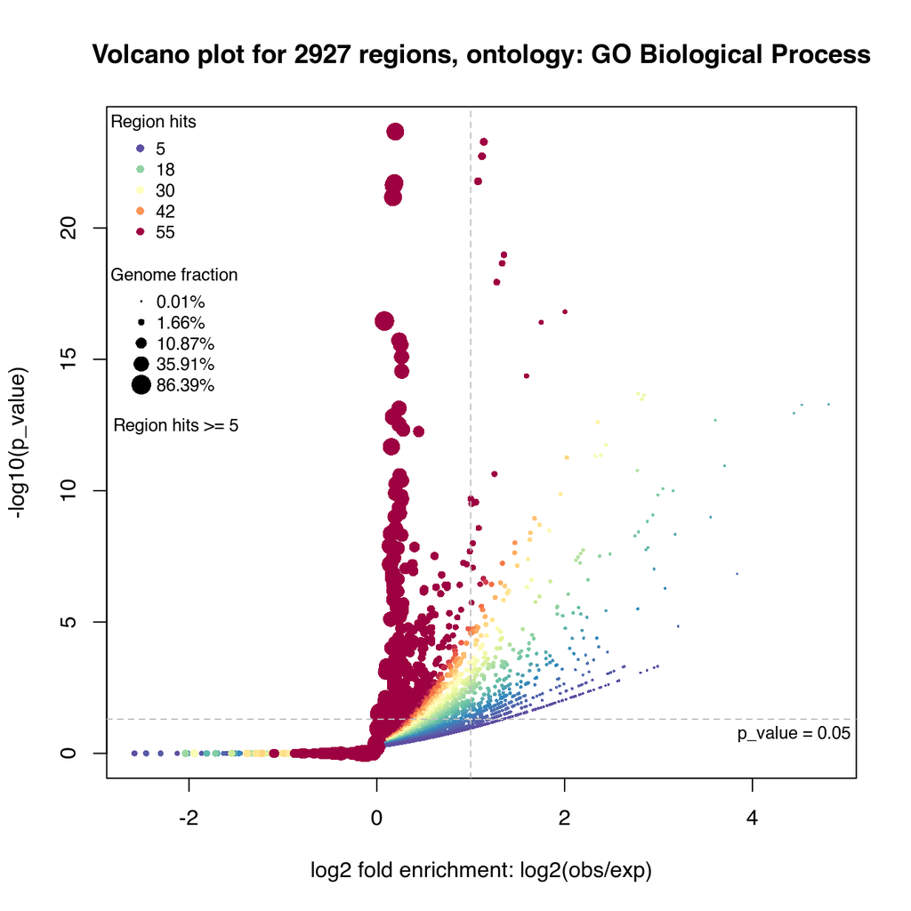

```r
plotVolcano(job, ontology = "GO Biological Process")
```

## Get region-gene associations

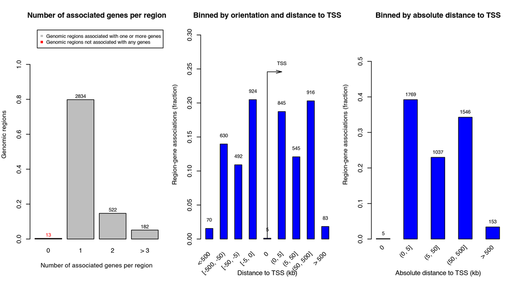

```r
plotRegionGeneAssociations(job)
```

```r
getRegionGeneAssociations(job)
```

```
GRanges object with 2914 ranges and 2 metadata columns:
         seqnames              ranges strand | annotated_genes    dist_to_TSS
            <Rle>           <IRanges>  <Rle> | <CharacterList>  <IntegerList>
     [1]     chr1       827430-827761      * |   OR4F16,SAMD11 -140922,-98143
     [2]     chr1     1019597-1019967      * |            AGRN           -341
     [3]     chr1     1079402-1080118      * | RNF223,C1orf159    -5453,36321
     [4]     chr1     1505040-1505335      * |   ATAD3A,ATAD3B    -6988,33418
     [5]     chr1     1614069-1614459      * |            MIB2          -1179
     ...      ...                 ...    ... .             ...            ...
  [2910]     chrX 149540764-149541085      * |        CXorf40A            282
  [2911]     chrX 151974673-151974942      * |           GABRE           -128
  [2912]     chrX 153689106-153689420      * |   SLC6A8,BCAP31     1164,34831
  [2913]     chrX 154378497-154378733      * |        FLNA,EMD     -3989,-582
  [2914]     chrX 154398747-154399024      * |           RPL10            655
  -------
  seqinfo: 23 sequences from an unspecified genome; no seqlengths
```

# 03 - Exercises

- 1. Repeat the Motif finding analysis and GSEA analysis using the data for HIF2a, which can be found here:

```bash
ls ../data/complete/RCC4_Normoxia_HIF2a_PM9_Rep1.bed
```

```
../data/complete/RCC4_Normoxia_HIF2a_PM9_Rep1.bed
```